# 04.2: Integration and Modularity

Dean Adams, Michael Collyer & Antigoni Kaliontzopoulou

08 October, 2019

## **Content Description**

In `geomorph`, one can assess the degree of morphological integration between two blocks of landmarks, using PLS, or apply the global integration test proposed by Bookstein (2015). Also, there are analytical tools for determining whether a set of a priori partitions provides evidence for modularity.

First, load the package and some example data:

```r
library(geomorph)
data(plethodon)
Y.gpa <- gpagen(plethodon$land, print.progress = FALSE)
```

## **Morphological Integration using PLS**

The example tests for integration between two subsets of a structure, but two different structures could be examined.

```r
integration.test(Y.gpa$coords[1:5,,], Y.gpa$coords[6:12,,], iter=999, print.progress = FALSE)
```

```
##
## Call:
## integration.test(A = Y.gpa$coords[1:5, , ], A2 = Y.gpa$coords[6:12,
##     , ], iter = 999, print.progress = FALSE)
##
##
##
## r-PLS: 0.911
##
## P-value: 0.001
##
## Based on 1000 random permutations
```

The same thing can be done using partitioning of the landmarks:

```r
integration.test(Y.gpa$coords, partition.gp=c(rep("A", 5), rep("B", 7)), iter=999, print.progress = FALSE)
```

```
##
## Call:
## integration.test(A = Y.gpa$coords, partition.gp = c(rep("A",
##     5), rep("B", 7)), iter = 999, print.progress = FALSE)
##
##
##
## r-PLS: 0.911
##
## P-value: 0.001
##
## Based on 1000 random permutations
```

And the statistical results are the same as when using two.b.pls

```r
two.b.pls(Y.gpa$coords[1:5,,], Y.gpa$coords[6:12,,], iter=999, print.progress = FALSE)
```

```
##
## Call:
## two.b.pls(A1 = Y.gpa$coords[1:5, , ], A2 = Y.gpa$coords[6:12,
##     , ], iter = 999, print.progress = FALSE)
##
##
##
## r-PLS: 0.911
##
## P-value: 0.001
##
## Based on 1000 random permutations
```

So, your global workflow for testing for integartion would be:

```r
pleth.integr <- integration.test(Y.gpa$coords[1:5,,], Y.gpa$coords[6:12,,], iter=999, print.progress = FALSE)
summary(pleth.integr)
```

```
##
## Call:
## integration.test(A = Y.gpa$coords[1:5, , ], A2 = Y.gpa$coords[6:12,
##     , ], iter = 999, print.progress = FALSE)
##
##
##
## r-PLS: 0.911
##
## P-value: 0.001
##
## Based on 1000 random permutations
```

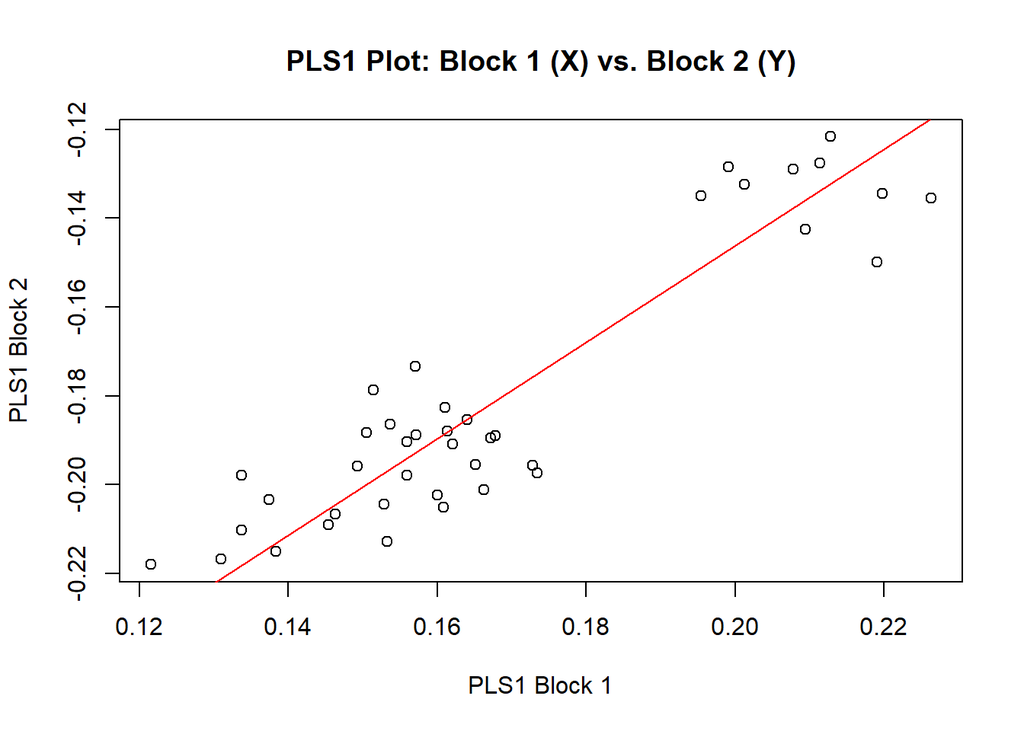

```r
plot(pleth.integr)
```

`picknplot.shape` example is provided in lab script.

## **Compare the Strength of Integraton**

One may want to ask whether integration is equally strong in two or more groups. This can be done by comparing z-scores calculated over the PLS correlation coefficients of previously applied integration analyses.

```r
gps <- factor(paste(plethodon$species, plethodon$site))
ljaw.gp <- coords.subset(Y.gpa$coords[1:5,,], gps)
ujaw.gp <- coords.subset(Y.gpa$coords[6:12,,], gps)
integ.tests <- Map(function(x,y) integration.test(x, y, iter=999, print.progress = FALSE),
                   ljaw.gp, ujaw.gp)
group.z <- compare.pls(integ.tests)
summary(group.z)
```

```
##
## Effect sizes
##
##  Jord Allo  Jord Symp Teyah Allo Teyah Symp
##  1.9388321  0.4655648  1.2384988  0.3493107
##
## Effect sizes for pairwise differences in PLS effect size
##
##            Jord Allo   Jord Symp Teyah Allo Teyah Symp
## Jord Allo  0.0000000  1.04227905  0.4954584 1.12452432
## Jord Symp  1.0422791  0.00000000 -0.5468207 0.08224527
## Teyah Allo 0.4954584 -0.54682065  0.0000000 0.62906592
## Teyah Symp 1.1245243  0.08224527  0.6290659 0.00000000
##
## P-values
##
##            Jord Allo Jord Symp Teyah Allo Teyah Symp
## Jord Allo  1.0000000 0.2972823  0.6202766  0.2607907
## Jord Symp  0.2972823 1.0000000  0.5845020  0.9344517
## Teyah Allo 0.6202766 0.5845020  1.0000000  0.5293059
## Teyah Symp 0.2607907 0.9344517  0.5293059  1.0000000
```

## **Test of Global Integration (Bookstein 2015)**

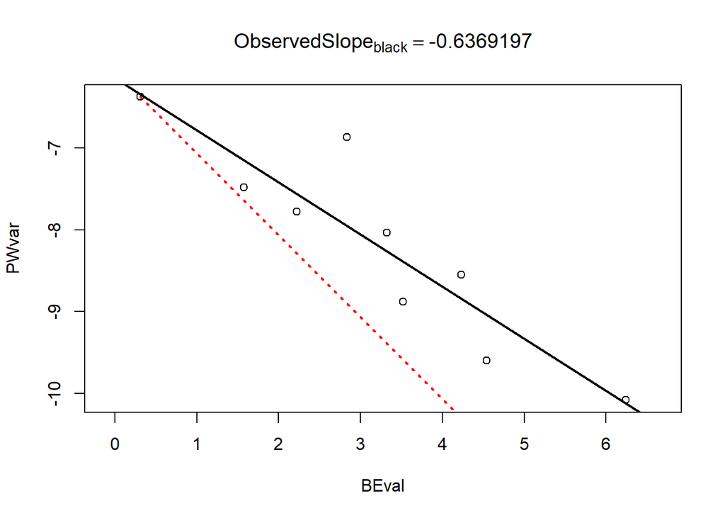

```
##      BEval
## -0.6369197
```

```r
globalIntegration(Y.gpa$coords)
```

## **Test of Modularity**

Tests of modularity are accomplished usin ghe $\small{CR}$ coefficient

```r
land.gps <- c("A","A","A","A","A","B","B","B","B","B","B","B") #specify partitions
modularity.test(Y.gpa$coords, land.gps, iter=999, print.progress = FALSE)
```

```
##
## Call:
## modularity.test(A = Y.gpa$coords, partition.gp = land.gps, iter = 999,
##     print.progress = FALSE)
##
##
##
## CR: 1.1876
##
## P-value: 0.706
##
## Based on 1000 random permutations
```

## **Compare the Strength of Modularity**

A recent advance (Adams and Collyer, 2019: Accepted) allows one to evaluate whether the degree of modular signal is equally strong in two or more different groups. This can be done by comparing z-scores calculated across CR-coefficients representing modular signal.

```r
data(pupfish)
 Y.gpa<-gpagen(pupfish$coords, print.progress = FALSE)    #GPA-alignment

## landmarks on the body and operculum
 land.gps<-rep('a',56); land.gps[39:48]<-'b'

 group <- factor(paste(pupfish$Pop, pupfish$Sex, sep = "."))
 levels(group)
```

```
## [1] "Marsh.F"    "Marsh.M"    "Sinkhole.F" "Sinkhole.M"
```

```r
 coords.gp <- coords.subset(Y.gpa$coords, group)

 modularity.tests <- lapply(1:nlevels(group), function(j) modularity.test(coords.gp[[j]],
  land.gps, iter = 499, print.progress = FALSE))
## the lapply function performs the modularity test on each 3D array in the lists provided

 modularity.tests[[1]]
```

```
##
## Call:
## modularity.test(A = coords.gp[[j]], partition.gp = land.gps,
##     iter = 499, print.progress = FALSE)
##
##
##
## CR: 0.966
##
## P-value: 0.214
##
## Based on 500 random permutations
```

```r
 modularity.tests[[2]]
```

```
##
## Call:
## modularity.test(A = coords.gp[[j]], partition.gp = land.gps,
##     iter = 499, print.progress = FALSE)
##
##
##
## CR: 0.692
##
## P-value: 0.002
##
## Based on 500 random permutations
```

```r
 modularity.tests[[3]]
```

```
##
## Call:
## modularity.test(A = coords.gp[[j]], partition.gp = land.gps,
##     iter = 499, print.progress = FALSE)
##
##
##
## CR: 0.822
##
## P-value: 0.004
##
## Based on 500 random permutations
```

```r
 modularity.tests[[4]]
```

```
##
## Call:
## modularity.test(A = coords.gp[[j]], partition.gp = land.gps,
##     iter = 499, print.progress = FALSE)
##
##
##
## CR: 0.94
##
## P-value: 0.03
##
## Based on 500 random permutations
```

```r
 group.Z <- compare.CR(modularity.tests, CR.null = FALSE)
 group.Z  ## NOTE: need a summary function
```

```
## $comment
## [1] "NOTE: more negative effects represent stronger modular signal!"
##
## $sample.z
##       CR.1       CR.2       CR.3       CR.4
## -0.6928208 -7.1970958 -3.2185472 -2.3011814
##
## $sample.r.sd
##      CR.1      CR.2      CR.3      CR.4
## 0.9989975 0.9989975 0.9989975 0.9989975
##
## $pairwise.z
##          CR.1      CR.2       CR.3       CR.4
## CR.1 0.000000  4.603832  1.7877505  1.1384240
## CR.2 4.603832  0.000000 -2.8160818 -3.4654084
## CR.3 1.787751 -2.816082  0.0000000 -0.6493265
## CR.4 1.138424 -3.465408 -0.6493265  0.0000000
##
## $pairwise.P
##              CR.1         CR.2        CR.3         CR.4
## CR.1 1.000000e+00 4.147864e-06 0.073816267 0.2549434820
## CR.2 4.147864e-06 1.000000e+00 0.004861328 0.0005294269
## CR.3 7.381627e-02 4.861328e-03 1.000000000 0.5161273391
## CR.4 2.549435e-01 5.294269e-04 0.516127339 1.0000000000
##
## attr(,"class")
## [1] "compare.CR"
```

## **Comparing Alternative Modular Hypotheses**

In like manner, one may wish to determine whether there is support in a given dataset for a 2-module, 3-module, 4-module, or other hypothesis. Such investigations ask: “What modular hypothesis best describes the patterns of covariation in my data?”. A recent advance (Adams and Collyer, 2019: Accepted) allows one to evaluate these hypotheses by comparing z-scores calculated across CR-coefficients representing modular signal.

```r
land.gps3 <- rep('a',56); land.gps3[39:48]<-'b'; land.gps3[c(6:9,28:38)] <- 'c'
   #3 module hypothesis (tail now a module)
 land.gps4 <- rep('a',56); land.gps4[39:48]<-'b'; land.gps4[c(6:9,28:38)] <- 'c';
  land.gps4[c(10,49:56)] <- 'd'  #4 module hypothesis (eye now a module)

 m3.test <- modularity.test(coords.gp$Marsh.F,land.gps3, iter = 499, print.progress = FALSE)
 m4.test <- modularity.test(coords.gp$Marsh.F,land.gps4, iter = 499, print.progress = FALSE)

 model.Z <- compare.CR(modularity.tests[[1]],m3.test,m4.test, CR.null = TRUE)
 model.Z
```

```
## $comment
## [1] "NOTE: more negative effects represent stronger modular signal!"
##
## $sample.z
## No_Modules       CR.1       CR.2       CR.3
##  0.0000000 -0.6928208 -3.1879143 -5.0835026
##
## $sample.r.sd
## No_Modules       CR.1       CR.2       CR.3
##  0.0000000  0.9989975  0.9989975  0.9989975
##
## $pairwise.z
##            No_Modules     CR.1     CR.2     CR.3
## No_Modules   0.000000 0.693516 3.191113 5.088604
## CR.1         0.693516 0.000000 1.766068 3.107796
## CR.2         3.191113 1.766068 0.000000 1.341728
## CR.3         5.088604 3.107796 1.341728 0.000000
##
## $pairwise.P
##              No_Modules        CR.1        CR.2         CR.3
## No_Modules 1.000000e+00 0.487985766 0.001417256 3.607090e-07
## CR.1       4.879858e-01 1.000000000 0.077384433 1.884878e-03
## CR.2       1.417256e-03 0.077384433 1.000000000 1.796841e-01
## CR.3       3.607090e-07 0.001884878 0.179684068 1.000000e+00
##
## attr(,"class")
## [1] "compare.CR"
```